# Chapter 7: Multivariate Analysis

#### Optimal lines

- Linear combination of variables define a line in higher dimensions, same as constructing lines in a scatterplot plane (2D)
  - Many ways to choose lines to project data but there is a “best line”
    - Total variance of all points in all variables can be de-decomposed
    - PCA -> total sums of squares distances between points & any line can be decomposed into distances to line & variance along line
- PC (variable calculated above for line question) minimizes distance to line & maximizes variance of projections along line
- Why maximize variance along line? - see following example of 3D -> 2D
- 17. Which of the 2 projections do you find more informative?

[figure not shown]

[figure not shown]

**The PCA workflow**<sup>Return</sup>

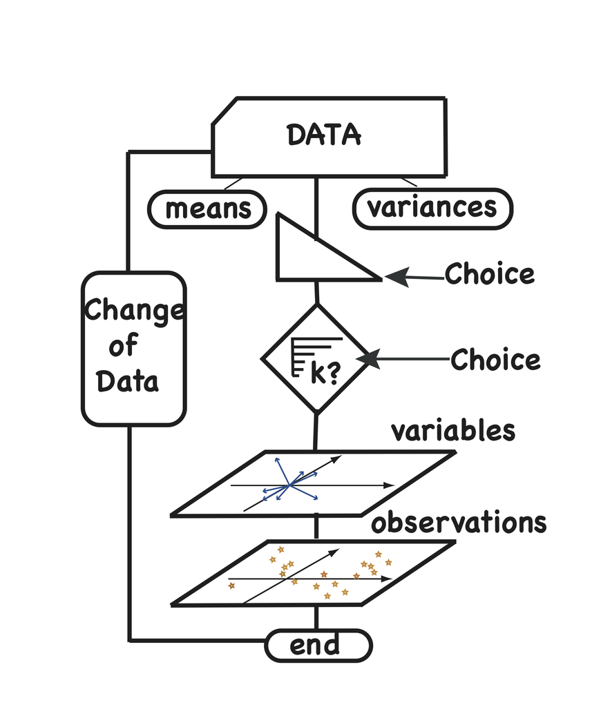

- PCA is based on finding axis w/ largest variability, removing the variability in that direction, and iterating to find next best orthogonal axis
  - Don’t have to run iterations -> all axes can be found via **Singular Value Decomposition (SVD)**
- In figure above
  1. Calculate means and variances
  2. Pick to work with rescaled covariences (correlation matrix) or not
  3. Pick *k*, number of components relevant to data (think she means eigenvalues & associated eigenvectors)
  - k = rank of the approximation chosen - give careful explaination of how choice is made
- Impossible to choose #of components before doing analysis (unlike clustering)
  - Choice of k needs visualization of the plot of variances & successive principal components before projecting the data
- End result of PCA workflow = useful maps for variables & samples
  - Understanding how maps are made will decrease information needed

**The inner workings of PCA: rank reduction**<sup>Return</sup>

- This section may require a background in linear algebra (even if faint)
  - Provides insight into SVD method used for PCA
- SVD (singular value decomposition) of a matrix is used to find horizontal & vertical vectors (singular vectors) & normalizing values (singular values) (S = UAV^t)

#### Rank-one matricies

- Simple generative model shows the meaning of rank of a matrix & how to find it
  - Suppose 2 vectors (*u* = a one column matrix)
  - Suppose v<sup>t</sup>=t(v) (a one row matrix - transposed from one column matrix v)
  - Multiply a copy of *u* by each elements of v<sup>t</sup> looks like the following
    - (row x col)
    - U = c(1,2,3,4) a col vector
    - Vt = c(2,4,8) a row vector
- Step1

| X | 2 | 4 | 8 |
| --- | --- | --- | --- |
| 1 |  |  |  |
| 2 |  |  |  |
| 3 |  |  |  |
| 4 |  |  |  |

- Step2

| X | 2 | 4 | 8 |
| --- | --- | --- | --- |
| 1 | 2 |  |  |
| 2 | 4 |  |  |
| 3 | 6 |  |  |
| 4 | 8 |  |  |

- Step3

| X | 2 | 4 | 8 |
| --- | --- | --- | --- |
| 1 | 2 | 4 |  |
| 2 | 4 | 8 |  |
| 3 | 6 | 12 |  |
| 4 | 8 | 16 |  |

- Step4

| X | 2 | 4 | 8 |
| --- | --- | --- | --- |
| 1 | 2 | 4 | 8 |
| 2 | 4 | 8 | 16 |
| 3 | 6 | 12 | 24 |
| 4 | 8 | 16 | 32 |

- Matrix X here is said to be rank-1 b/c *u* and *v* both have one column (note not V<sup>t</sup> which is mentioned here… this is completely misleading. U is matrix w/ 1 col & V (the untransposed V<sup>t</sup>) is also a matrix w/ 1 col)

$u = ( 1 2 3 4 )$

&

$v = ( 2 4 8 )$

The (2, 3) entry of the matrix X, written x<sub>2, 3</sub>, is obtained by multiplying u<sub>2</sub> by v<sub>3</sub>. We can write this

$$X = ( 2 4 8 4 8 16 6 12 24 8 16 32 ) = u ∗ t ( v ) = u ∗ v t$$

> Note - row X col (v<sup>t</sup> * u)
- 17. Why can we say X=u*v<sup>t</sup> is better than spelling out the whole matrix?
- 1. If we wanted to reverse the process & simplify another matrix X. Can we express it in a similar way as a product of vectors w/o loss of info?
- 17. decompose this matrix

$$\begin{equation}
\begin{array}{rrrrr}
\hline
{\large X} & x_{.1} & x_{.2} & x_{.3} & x_{.4} \\
\hline
x_{1.} & 780 & 936 & 1300 & 728\\
x_{2.} & 75 & 90 & 125 & 70\\
x_{3.} & 540 & 648 & 900 & 504\\
\hline
\end{array}
\tag{7.3}
\end{equation}$$

- X has been redrawn as a series of rectangles as follows (coloured boxes = areas proportional to numbers in cells of the matrix)

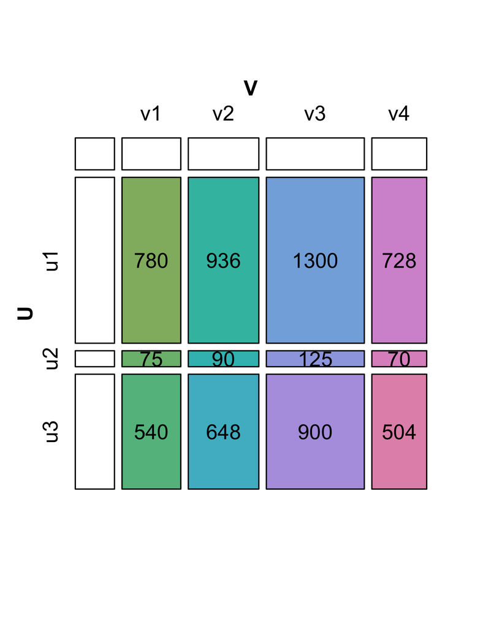

> Some special matrices have numbers in them that make them easy to decompose. Each colored rectangle in this diagram has an area that corresponds to the number in it.
- What numbers can we put in the white *u* & *v* boxes so the values of the sides of the rectangle give the numbers as their products?
  - A matrix w/ special property of being perfect “rectangular” (ex) matrix X) said to be rank-1
  - Can represent the numbers in X by areas of rectangles - sides of rectangles are given by values in side vectors (*u* & *v*)

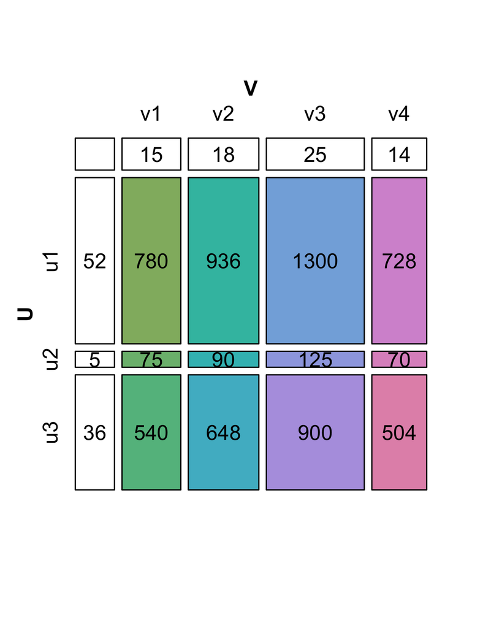

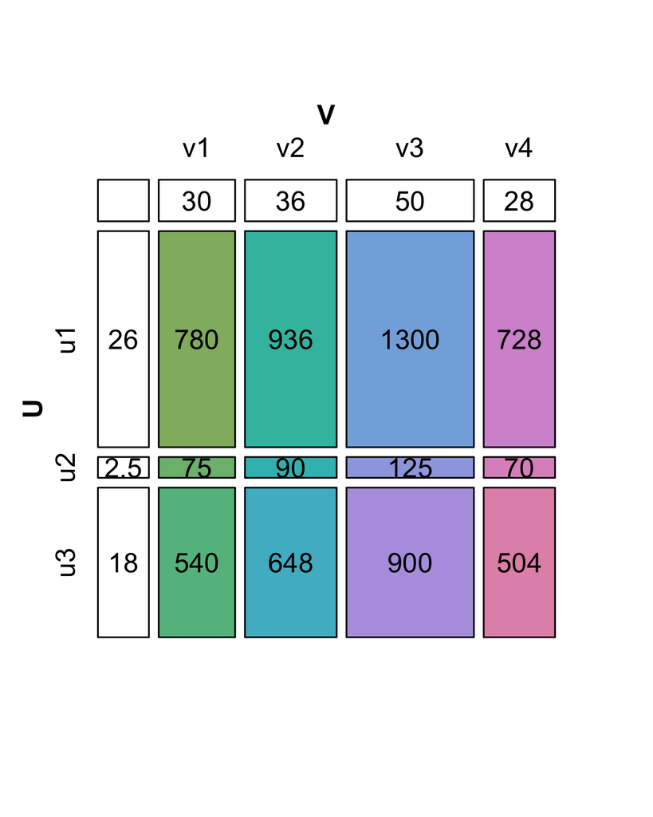

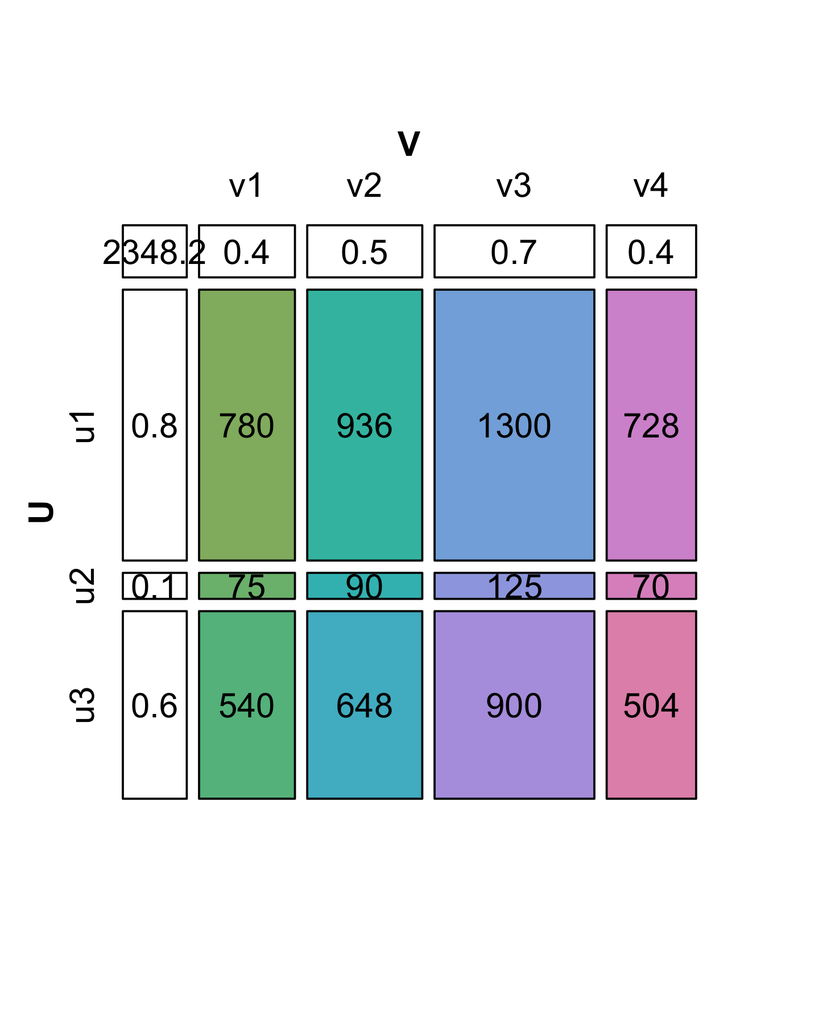

```r
#Check multiplication & norm properties
X = matrix(c(780,  75, 540,
             936,  90, 648,
            1300, 125, 900,
             728,  70, 504), nrow = 3)
u = c(0.8196, 0.0788, 0.5674)
v = c(0.4053, 0.4863, 0.6754, 0.3782)
s1 = 2348.2
sum(u^2)
```

```
[1] 0.9998964
```

```r
sum(v^2)
```

```
[1] 0.9999562
```

```r
s1*u %*% t(v)
```

```
          [,1]      [,2]      [,3]      [,4]
[1,] 780.03419 935.92555 1299.8645 727.87794
[2,]  74.99597  89.98406  124.9748  69.98143
[3,] 540.00903 647.93089  899.8818 503.90183
```

```r
X-s1*u %*% t(v)
```

```
             [,1]       [,2]       [,3]       [,4]
[1,] -0.034187016 0.07445066 0.13548011 0.12205890
[2,]  0.004033752 0.01594279 0.02522674 0.01856789
[3,] -0.009026004 0.06911092 0.11819353 0.09816522
```

- 17. Try svd(X) and look for components of the output of `svd()` function
  - Check norm of the columns of the matracies that result from this
  - Where did the value s1=2348.2 come from?

```r
svd(X)$u[, 1]
```

```
[1] 0.81963482 0.07881104 0.56743949
```

```r
svd(X)$v[, 1]
```

```
[1] 0.4052574 0.4863089 0.6754290 0.3782403
```

```r
sum(svd(X)$u[, 1]^2)
```

```
[1] 1
```

```r
sum(svd(X)$v[, 1]^2)
```

```
[1] 1
```

```r
svd(X)$d #these are singular values (square roots of eigenvalues)
```

```
[1] 2.348244e+03 2.141733e-13 6.912584e-15
```

- In this case, can see the 2nd & 3rd singular values are 0 (not looking at decimals - 2.141733e-13 6.912584e-15)
  - This is why we say matrix X is rank-1
- Usually in other matricies X, it is rare to write X as this two-vector product
  - Next shown, how to decompose X when it is not rank-1

#### How do we find such a decomposition in a unique way?

- Above decomposition = 3elements (horizontal, vertical, single vectors, and diagonal corner(singular value))
  - Can find these via singular value decomposition function (svd)

```r
#example
Xtwo = matrix(c(12.5, 35.0, 25.0, 25, 9, 14, 26, 18, 16, 21, 49, 32,
       18, 28, 52, 36, 18, 10.5, 64.5, 36), ncol = 4, byrow = TRUE)
USV = svd(Xtwo)
```

- 17. Look at USV object (result from svd() function). What are the components?

```r
names(USV)
```

```
[1] "d" "u" "v"
```

```r
USV$d #singular values
```

```
[1] 1.350624e+02 2.805191e+01 3.103005e-15 1.849559e-15
```

135.1 is the first singular value in USV$d[1] (1.351*e02)

- 17. Check how each succesive pair of singular vectors improves approximation of Xtwo. What do you notice about the 3rd & 4th singular values?

```r
Xtwo - USV$d[1] * USV$u[, 1] %*% t(USV$v[, 1])
```

```
            [,1]       [,2]        [,3]        [,4]
[1,]  0.87481760  19.045230 -10.1044650  1.74963521
[2,]  0.08079747   1.759002  -0.9332405  0.16159494
[3,] -0.04700978  -1.023427   0.5429803 -0.09401956
[4,]  0.16159494   3.518005  -1.8664809  0.32318987
[5,] -0.69632883 -15.159437   8.0428540 -1.39265765
```

```r
Xtwo - USV$d[1] * USV$u[, 1] %*% t(USV$v[, 1]) -
       USV$d[2] * USV$u[, 2] %*% t(USV$v[, 2])
```

```
             [,1]          [,2]         [,3]         [,4]
[1,] 7.216450e-15 -1.065814e-14 8.881784e-15 4.884981e-15
[2,] 2.040035e-15 -5.995204e-15 1.054712e-14 3.219647e-15
[3,] 2.865763e-15 -9.547918e-15 1.554312e-15 6.231127e-15
[4,] 4.385381e-15 -5.773160e-15 1.776357e-14 7.049916e-15
[5,] 5.107026e-15 -1.776357e-15 1.776357e-14 1.776357e-14
```

- 3rd & 4th values are small, don’t improve approximation -> conclude Xtwo is rank-2 (b/c 2 singular values/4 are above 0)
- Many ways to write rank-2 matrix (ex) Xtwo) as sum of rank-1 matrix
  - in order to ensure uniqueness, we add another condition to the singular vectors (above used norm of vectors=1)
- Output vectors of singular decomposition don’t have only norms=1
  - each vector in U matrix is ortogonal to all previous
  - Same for V matrix (
    $$\begin{equation}u_{\bullet 1} \perp u_{\bullet 2}\end{equation}$$
    -> sum of products of values in the same positons is 0)
    $$\begin{equation}\sum_i u_{i1} u_{i2} = 0\end{equation}$$
- Task: Check ortonormality by computing cross product of U & V matracies

```r
t(USV$u) %*% USV$u
```

```
              [,1]          [,2]          [,3]          [,4]
[1,]  1.000000e+00 -1.665335e-16  0.000000e+00 -8.326673e-17
[2,] -1.665335e-16  1.000000e+00  1.665335e-16 -5.551115e-17
[3,]  0.000000e+00  1.665335e-16  1.000000e+00 -5.551115e-17
[4,] -8.326673e-17 -5.551115e-17 -5.551115e-17  1.000000e+00
```

```r
t(USV$v) %*% USV$v
```

```
              [,1]          [,2]          [,3]          [,4]
[1,]  1.000000e+00  8.326673e-17  1.387779e-17 -5.551115e-17
[2,]  8.326673e-17  1.000000e+00 -3.642919e-17 -6.938894e-17
[3,]  1.387779e-17 -3.642919e-17  1.000000e+00  2.775558e-17
[4,] -5.551115e-17 -6.938894e-17  2.775558e-17  1.000000e+00
```

- Submit rescaled turtles matrix to SVD

```r
turtles.svd = svd(scaledTurtles)
turtles.svd$d #singular values (squared eigenvalues)
```

```
[1] 11.746475  1.419035  1.003329
```

```r
turtles.svd$v #v matrix (A)^t(A)
```

```
          [,1]       [,2]        [,3]
[1,] 0.5787981 -0.3250273 -0.74789704
[2,] 0.5779840 -0.4834699  0.65741263
[3,] 0.5752628  0.8127817  0.09197088
```

```r
dim(turtles.svd$u) #u matrix (A)(A)^t
```

```
[1] 48  3
```

- 17. What can be concluded from tutles matrix resulting svd output?
- 1. 1st column of turtles.svd$v shows coefficients for 3 variables which are ~equal
  - Other noticeable coincidences

```r
sum(turtles.svd$v[,1]^2)
```

```
[1] 1
```

```r
sum(turtles.svd$d^2) / 47
```

```
[1] 3
```

Coefficients are srt(1/3) & sum of squares of the singular values is = (n-1)xp

#### **Singular value decomposition**

- X is decomposed additively into rank-1 pieces
  - Each *u* vectors is combined into U matrix
  - Each *v* vectors is combined into V matrix
- SVD is

$$\begin{equation}
{\mathbf X} = U S V^t, V^t V={\mathbb I}, U^t U={\mathbb I},
\tag{7.4}
\end{equation}$$

- Where
  - S = diagonal matrix of singular values
  - V<sup>t</sup> is the transposed V
  - I = Identity matrix
- Can rewite element-wise as

$$\begin{equation*}
X_{ij} = u_{i1}s_1v_{1j} + u_{i2}s_2v_{2j} + u_{i3}s_3v_{3j} +... +
u_{ir}s_rv_{rj},
\end{equation*}$$

- **U & V are said to be orthonormal (norm=1 - not related to normal distribution) b/c self-crossproducts are identity matrix**

```r
#check this statement
round(crossprod(USV$v, USV$v),1)
```

```
     [,1] [,2] [,3] [,4]
[1,]    1    0    0    0
[2,]    0    1    0    0
[3,]    0    0    1    0
[4,]    0    0    0    1
```

```r
round(crossprod(USV$u, USV$u),1)
```

```
     [,1] [,2] [,3] [,4]
[1,]    1    0    0    0
[2,]    0    1    0    0
[3,]    0    0    1    0
[4,]    0    0    0    1
```

Confirmed

#### Princial components

- Singular vectors from the SVD (`svd()`) contain coefficents to put in front of original variables to make more informative = Principal component
  - Written as

$$\begin{equation*}
Z_1=c_1 X_{\bullet 1} +c_2 X_{\bullet 2}+ c_3 X_{\bullet 3}+\cdots c_p X_{\bullet p}.
\end{equation*}$$

- If usv=svd(X), then (c1, c2, c3, …) given by 1st column of usv$v
  - New variables Z1,Z2,Z3,… will have variences decreasing in size
    $$\begin{equation}s_1^2 \geq s_2^2 \geq s_3^2 \geq ...\end{equation}$$
- Q) Compute 1st PC for turtles data by multiplying by 1st singular value of usv$d[1] by usv$u[,1]. What is another way of computing it?

```r
turtles.svd$d[1] %*% turtles.svd$u[,1]
```

```
          [,1]      [,2]      [,3]      [,4]       [,5]       [,6]
[1,] -1.983668 -1.705579 -1.340216 -1.420782 -0.9423811 0.04689258
            [,7]    [,8]      [,9]     [,10]     [,11]     [,12]
[1,] -0.09048395 0.71721 0.8540019 0.8540019 0.5854404 0.8016959
         [,13]    [,14]    [,15]   [,16]    [,17]    [,18]    [,19]
[1,] 0.7846503 0.858507 1.353953 1.93447 1.808307 1.989887 2.890979
        [,20]    [,21]    [,22]    [,23]    [,24]     [,25]     [,26]
[1,] 2.776548 2.907215 3.140809 3.362087 4.562009 -2.512689 -2.439124
         [,27]     [,28]     [,29]     [,30]     [,31]     [,32]
[1,] -2.291411 -1.693556 -1.688242 -1.910913 -1.654375 -1.597856
         [,33]     [,34]     [,35]     [,36]      [,37]      [,38]
[1,] -1.683736 -1.086174 -1.103512 -1.166447 -0.7219127 -0.8307375
          [,39]      [,40]      [,41]     [,42]      [,43]      [,44]
[1,] -0.7851402 -0.6374268 -0.8600987 -0.403541 -0.4211712 -0.1937018
             [,45]       [,46]     [,47]     [,48]
[1,] -0.0003910952 -0.01772898 0.1355914 0.8187415
```

```r
scaledTurtles %*% turtles.svd$v[,1]
```

```
               [,1]
 [1,] -1.9836684602
 [2,] -1.7055794726
 [3,] -1.3402164350
 [4,] -1.4207818191
 [5,] -0.9423811150
 [6,]  0.0468925757
 [7,] -0.0904839545
 [8,]  0.7172099610
 [9,]  0.8540018654
[10,]  0.8540018654
[11,]  0.5854403531
[12,]  0.8016958980
[13,]  0.7846503260
[14,]  0.8585070441
```

[output cut: 34 more lines]

**Matrix multiplications can show that XV & US are the same**  
* Remember V is orthogonal (so V<sup>t</sup>V = I & XV=USV<sup>t</sup>V=USI) -> where I = identity matrix

- If lost about which output matracies to deal with, think of dimension of PCs
  - each C=(c1,c2,…,cp) is of length n (#of observations)
  - n is also the number of rows of each of the vectors X1, X2,..,Xp
- 2 useful facts
  - ?? always chosen to be less than # of original variables or #of observations
    - Lowering the dimension problem:

  $$\begin{equation*}
  k\leq \min(n,p)
  \end{equation*}$$
- **PC Transformation**
  - 1st PC has the largest varience (accounts for most vatiability in data as possible)
  - Each successive PC has highest varience possible
    - Constrained due to having to be ortogonal to preceeding components

$$\begin{equation*}
\max_{aX \perp bX}\mbox{var}(\mbox{Proj}_{aX} (X)), \qquad \mbox{where } bX=\mbox{previous components}
\end{equation*}$$

**Plotting the observations in the principal plane**<sup>Return</sup>

> In fact, PCA is such a fundamental technique that there are many different implementations of it in various R packages. Unfortunately, the input arguments and the formating and naming of their output is not standardized, and some even use different conventions for the scaling of their output. We will experiment with several different ones to familiarize ourselves with these choices.
- Using atheletes data ($discus & $weight) * Previously found prinipal component (PC) - the purple line in dimension reduction (above) * Showed that Z1 is the linear combination of the diagonal * Coefficients sum of squares must add to 1, so Z1=(-0.707*athletes$disc)-(0.707*athletes$weight)

```r
svda$v[,1]
```

```
[1] -0.7071068 -0.7071068
```

> This is the same as if the two coordinates were c1 = 0.7071 and c2 = 0.7071.
- 17. What part of the output of svd functions leads us to the **first PC coefficients, also known as PC loadings?**

```r
svda$v[,1]
```

```
[1] -0.7071068 -0.7071068
```

- If we roate the plane (discus, weight) into making the purple line the horizontal x-axis -> this is the **first principal plane**

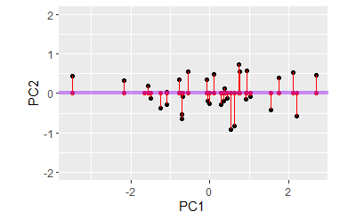

```r
ppdf = tibble(PC1n = -svda$u[, 1] * svda$d[1], #PC1 values is U[col1] %*% singularvalue[1] put into tibble
              PC2n = svda$u[, 2] * svda$d[2]) #PC2 values is U[col2] %*% singularvalue[2] put into tibble
ggplot(ppdf, aes(x = PC1n, y = PC2n)) + geom_point() + xlab("PC1 ")+
    ylab("PC2") + geom_point(aes(x=PC1n,y=0),color="red") +
    geom_segment(aes(xend = PC1n, yend = 0), color = "red") +
    geom_hline(yintercept = 0, color = "purple", lwd=1.5, alpha=0.5) +
    xlim(-3.5, 2.7) + ylim(-2,2) + coord_fixed()
```

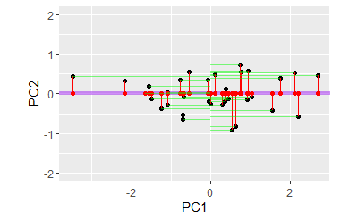

```r
#no clue what this is trying to show
segm = tibble(xmin = pmin(ppdf$PC1n, 0), xmax = pmax(ppdf$PC1n, 0), yp = seq(-1, -2, length = nrow(ppdf)), yo = ppdf$PC2n)
ggplot(ppdf, aes(x = PC1n, y = PC2n)) + geom_point() + ylab("PC2") + xlab("PC1") +
    geom_hline(yintercept=0,color="purple",lwd=1.5,alpha=0.5) +
    geom_point(aes(x=PC1n,y=0),color="red")+
    xlim(-3.5, 2.7)+ylim(-2,2)+coord_fixed() +
    geom_segment(aes(xend=PC1n,yend=0), color="red")+
    geom_segment(data=segm,aes(x=xmin,xend=xmax,y=yo,yend=yo), color="green",alpha=0.5)
```

> In the case where we only have two original variables, the PCA transformation is a simple rotation; the new coordinates are always chosen to be the horizontal and vertical axes.
- - 1. What is the mean of the sums of squares of the red segments?
  - 2. How does this compare to the varience of the red points?
  - 3. Compute ratio of the stdev of red segments to green segements. Compare this to ratio of singular values 1 & 2
- - 1. Mean sums of squares of red segments = square of 2nd singular value

```r
svda$d[2]^2
```

```
[1] 6.196729
```

```r
var(ppdf$PC1n)
```

```
[1] 1.806352
```

- 3. Take ratios of stdev of pts on vertical & horizontal axes via

```r
sd(ppdf$PC1n)/sd(ppdf$PC2n)  #horizontal PC1 vs vertical PC2
```

```
[1] 3.054182
```

```r
svda$d[1]/svda$d[2] #or singular value 1 vs singular value 2
```

```
[1] 3.054182
```

- Use `prcomp()` to find PCA of the 1st 2 columns of athletes dataset - look at output then compare to `svd()`

```r
prcomp(athletes[,1:2])
```

```
Standard deviations (1, .., p=2):
[1] 1.2407931 0.6785517

Rotation (n x k) = (2 x 2):
            PC1        PC2
m100 -0.7071068 -0.7071068
long  0.7071068 -0.7071068
```

```r
svd(athletes[,1:2])$v
```

```
           [,1]       [,2]
[1,] -0.7071068 -0.7071068
[2,]  0.7071068 -0.7071068
```

#### PCA of turtles data

- “true” dimensionality of rescaled data (scaledTurtles)
  - Use `prcomp()` to list all values needed to plot PCA

```r
cor(scaledTurtles) #generate a correlation matrix
```

```
          length     width    height
length 1.0000000 0.9783116 0.9646946
width  0.9783116 1.0000000 0.9605705
height 0.9646946 0.9605705 1.0000000
```

```r
# Find PCs
pcaturtles <-  princomp(scaledTurtles)
pcaturtles
```

```
Call:
princomp(x = scaledTurtles)

Standard deviations:
   Comp.1    Comp.2    Comp.3
1.6954576 0.2048201 0.1448180

 3  variables and  48 observations.
```

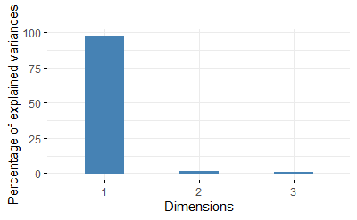

```r
fviz_eig(pcaturtles, geom = "bar", bar_width = 0.4) + ggtitle("")
```

> The screeplot shows the eigenvalues for the standardized turtles data (scaledTurtles): there is one large value and two small ones.The data are (almost) one-dimensional. We will see why this dimension is called an axis of size, a frequent phenomenon in biometric data.
- 17. Many PCA functions created by different people -> problematic naming conventions
  - Compare 4 of them & look at the results
  - What happens when you disable the scaling in the prcomp and princomp functions?

```r
svd(scaledTurtles)$v[, 1]
```

```
[1] 0.5787981 0.5779840 0.5752628
```

```r
prcomp(turtles[, -1])$rotation[, 1]
```

```
   length     width    height
0.8068646 0.4947448 0.3227958
```

```r
princomp(scaledTurtles)$loadings[, 1]
```

```
   length     width    height
0.5787981 0.5779840 0.5752628
```

```r
ade4::dudi.pca(turtles[, -1], nf = 2, scannf = FALSE)$c1[, 1]
```

```
[1] -0.5787981 -0.5779840 -0.5752628
```

- Comparable when scalings on (default = off)

```r
svd(scaledTurtles)$v[, 1]
```

```
[1] 0.5787981 0.5779840 0.5752628
```

```r
prcomp(turtles[, -1], scale=T)$rotation[, 1]
```

```
   length     width    height
0.5787981 0.5779840 0.5752628
```

```r
princomp(scaledTurtles, cor=T)$loadings[, 1] #cor is the scaling for princomp
```

```
   length     width    height
0.5787981 0.5779840 0.5752628
```

```r
ade4::dudi.pca(turtles[, -1], nf = 2, scannf = FALSE)$c1[, 1]
```

```
[1] -0.5787981 -0.5779840 -0.5752628
```

- For the following, assume matrix X is centered (mean subtracted) & scaled (div stdev)
- 17. Coordinates ofthe observations in the new variables from `prcomp()` = res -> prcomp()$scores
  - Look at PC1 for scaledTurtles & compare to res$scores
  - Compare stdev sd1 to res & stdev of scores

```r
res = princomp(scaledTurtles)
PC1 = scaledTurtles %*% res$loadings[,1] #compute PC1 using A x v
sd1 = sqrt(mean(res$scores[, 1]^2))
```

- Combine PC scores (U*S matrix) & loading-coefficients(V)
  - **Plots w/ both samples & variables represented = biplot (PCA score + loarding plot)**
  - use factoextra package

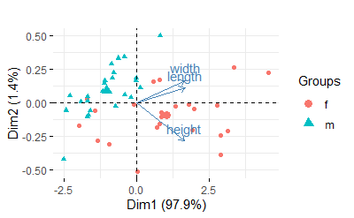

```r
fviz_pca_biplot(pcaturtles, label="var", habillage = turtles[,1]) + ggtitle("")
```

> A biplot of the first two dimensions showing both variables and observations. The arrows show the variables. The turtles are labeled by sex. The extended horizontal direction is due to the size of the first eigenvalue, which is much larger than the second.

> Beware the aspect ratio when plotting a PCA. It is rare to have the two components be of similar norm, so square shaped plots will be the exception. More common are elongated plots, which show that the horizontal (first) principal component is more important than the second. This matters, e.g., for interpreting distances between points in the plots.
- 17. Is it possible to have a PCA plot with the PC1 as the horizontal axis whose height is longer than its width?

> The variance of points in the PC1 direction is
> $$\begin{equation}\lambda_1=s_1^2\end{equation}$$
> which is always larger than
> $$\begin{equation}\lambda_2=s_2^2\end{equation}$$
> , so the PCA plot will always be wider than high.
- 17. Looking at the above biplot, does male or female turtles tend to be larger & what do the arrows tell us about the correlations?
- 1. Larger in terms of what (width or length?). Arrows tell if variable is +ve/-ve correlated
- 17. Compare variance of each new coordinate to the eigenvalues produced by PCA `dudi.pca()` - no clue what’s happening here

```r
pcadudit = dudi.pca(scaledTurtles, nf = 2, scannf = FALSE)
apply(pcadudit$li, 2, function(x) sum(x^2)/48)
```

```
     Axis1      Axis2
2.93573765 0.04284387
```

```r
pcadudit$eig
```

```
[1] 2.93573765 0.04284387 0.02141848
```

- Look at relationships between variables (old vs new)
  - Do this by drawing a **correlation circle**
    - Aspect ratio=1 & variables represented by arrows
    - Lengths of arrows indicate quality of projections onto PC1

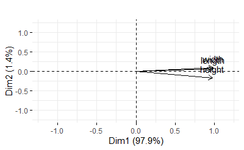

```r
fviz_pca_var(pcaturtles, col.circle = "black") + ggtitle("") +
  xlim(c(-1.2, 1.2)) + ylim(c(-1.2, 1.2))
```

> Part of the “circle of correlations” showing the original variables. Their correlations with each other and with the new principal components are given by the angles between the vectors and between the axes and the vectors
- 17. Explain the relationships between the number of rows of our turtles data matrix and the following numbers:

```r
svd(scaledTurtles)$d/pcaturtles$sdev
```

```
  Comp.1   Comp.2   Comp.3
6.928203 6.928203 6.928203
```

```r
sqrt(47)
```

```
[1] 6.855655
```

> When computing the variance covariance matrix, many implementations use 1 / (n−1) as the denominator. Here, n = 48 so the sum of the variances are off by a factor of 48/47.

> If we only want the first one then it is just c1 = s1u1 note  
> $| | c 1 | | 2 = s 1 t u 1 u 1 t s 1 = s 1 2 u 1 t u 1 = s 1 2 = λ 1$
- This is a good example that all variation in data can be captured in low-dimensional space
  - 3D data replaced by a line here
- X<sup>t</sup>C=VSUtUS=VS2
  - **The principal components (PC) = columns of the matrix C=US**
  - p columns of U (matrix of USV$u) = output from `svd()` -> rescaled to have norms (s<sub>1</sub><sup>2</sup>,s<sub>2</sub><sup>2</sup>,…,s<sub>p</sub><sup>2</sup>)
    - Each column has a different variance to explain (note in decreasing #’s)
- If matrix X is from study of n different samples, then PC generates new coordinates for the n points (**called scores in results of PCA functions**)

> Eigen decompositions = crossproduct of X with itself satifies  
> X<sup>t</sup>X = VSU<sup>t</sup>USV<sup>t</sup>=VS<sup>2</sup>V<sup>t</sup>=VΛV<sup>t</sup>  
> V = eigenvector matrix of symmetric matrix X<sup>t</sup>X  
> Λ is the diagonal matrix of eigenvalues of X<sup>t</sup>X
- Summary of SVD and PCA
  - Each PC has varience measured by eigenvalue (square of associated singular value)
  - New (transformed) variables are orthogonal
    - Since they are also centered -> they are uncorrelated (in normal distriubted data = independent data)
  - When variables rescaled, sum of variences of all variables = #of variables(=p)
    - sum of variences computed by adding diagonal crossproduct matrix
      - Sum of diagonal elements = **trace** of matrix
  - PCs are ordered by size of the eigenvalues
    - Use screeplot to decide how mnay components (eigenvalues) to keep
      - Use biplot & annotate each PC axis w/ proportion of varience explained

#### Complete analysis: decathlon athletes (step by step)

- First, look at rounded correlation matrix to see essential bivariate associations

```r
cor(athletes) %>% round(1)
```

```
       m100 long weight highj m400 m110 disc pole javel m1500
m100    1.0 -0.5   -0.2  -0.1  0.6  0.6  0.0 -0.4  -0.1   0.3
long   -0.5  1.0    0.1   0.3 -0.5 -0.5  0.0  0.3   0.2  -0.4
weight -0.2  0.1    1.0   0.1  0.1 -0.3  0.8  0.5   0.6   0.3
highj  -0.1  0.3    0.1   1.0 -0.1 -0.3  0.1  0.2   0.1  -0.1
m400    0.6 -0.5    0.1  -0.1  1.0  0.5  0.1 -0.3   0.1   0.6
m110    0.6 -0.5   -0.3  -0.3  0.5  1.0 -0.1 -0.5  -0.1   0.1
disc    0.0  0.0    0.8   0.1  0.1 -0.1  1.0  0.3   0.4   0.4
pole   -0.4  0.3    0.5   0.2 -0.3 -0.5  0.3  1.0   0.3   0.0
javel  -0.1  0.2    0.6   0.1  0.1 -0.1  0.4  0.3   1.0   0.1
m1500   0.3 -0.4    0.3  -0.1  0.6  0.1  0.4  0.0   0.1   1.0
```

- Second, look at screeplot to choose rank k for data
  - This shows eigenvalues in screeplot (where the clear drop appears - should be the afther the 2nd value in this data)
    - Good approximation for how many eigen values to keep (in this case rank2)

```r
pca.ath <- dudi.pca(athletes, scannf=F)
pca.ath$eig
```

```
 [1] 3.4182381 2.6063931 0.9432964 0.8780212 0.5566267 0.4912275 0.4305952
 [8] 0.3067981 0.2669494 0.1018542
```

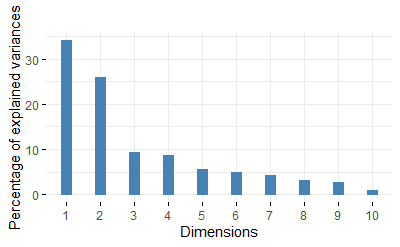

```r
fviz_eig(pca.ath, geom="bar", bar_width=0.3) + ggtitle("")
```

> The screeplot is the first thing to consult, it tells us that it is satisfactory to use a two-dimensional plot.
- Interpretation of 1st 2 axes by projecting loadings of original variables projected onto new variables
  - Correlation circle shows projection of original variables onto 2new principal axes
    - Angles between vectors = correlations

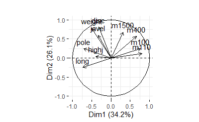

```r
fviz_pca_var(pca.ath, col.circle="black") + ggtitle("")
```

> Correlation circle of the original variables. Right side of plane = track & field events (m100-m1500), left side of plane = throwing + jumping events
- Is there an opposition of skills characterized by the correlation matrix? (-ve correlation between variables of the 2 groups)
  - How to interpret?
    - Those who threw best have lower scores in track
    - Athletes running short times are stronger (same w/ best throwers & jumpers)
      - should change scores of track variables & redo analysis
- 17. What transformations of variables make best athletic performances to vary in same direction (most positively correlated)
- 1. Change signs on the running performances -> most variables will become +ve correlated

```r
athletes[,c(1,5,6,10)] = -athletes[,c(1,5,6,10)]
cor(athletes) %>% round(1)
```

```
       m100 long weight highj m400 m110 disc pole javel m1500
m100    1.0  0.5    0.2   0.1  0.6  0.6  0.0  0.4   0.1   0.3
long    0.5  1.0    0.1   0.3  0.5  0.5  0.0  0.3   0.2   0.4
weight  0.2  0.1    1.0   0.1 -0.1  0.3  0.8  0.5   0.6  -0.3
highj   0.1  0.3    0.1   1.0  0.1  0.3  0.1  0.2   0.1   0.1
m400    0.6  0.5   -0.1   0.1  1.0  0.5 -0.1  0.3  -0.1   0.6
m110    0.6  0.5    0.3   0.3  0.5  1.0  0.1  0.5   0.1   0.1
disc    0.0  0.0    0.8   0.1 -0.1  0.1  1.0  0.3   0.4  -0.4
pole    0.4  0.3    0.5   0.2  0.3  0.5  0.3  1.0   0.3   0.0
javel   0.1  0.2    0.6   0.1 -0.1  0.1  0.4  0.3   1.0  -0.1
m1500   0.3  0.4   -0.3   0.1  0.6  0.1 -0.4  0.0  -0.1   1.0
```

```r
pcan.ath <- dudi.pca(athletes, nf=2, scannf=F)
pcan.ath$eig
```

```
 [1] 3.4182381 2.6063931 0.9432964 0.8780212 0.5566267 0.4912275 0.4305952
 [8] 0.3067981 0.2669494 0.1018542
```

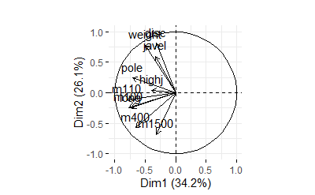

```r
fviz_pca_var(pcan.ath, col.circle="black") + ggtitle("")
```

> Correlation circle after changing the signs of the running variables.
- This correlation circle i the transformed variable
  - can an axis of size (all arrows pointing same direction)
- All -ve coorelations are small
  - screeplot shows no change b/c eigenvalues are unchanged
  - Signs in coefficents of PC loadings for m variables are the only outputs that change
- Plot atheletes projected in 1st PC

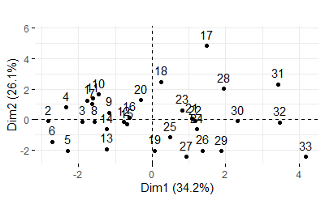

```r
fviz_pca_ind(pcan.ath) + ggtitle("") + ylim(c(-2.5,5.7))
```

> First principal plane showing the projections of the athletes. Do you notice something about the organization of the numbers?
- 17. Look at athletes themselves shown by above graph - notice slight ordering effect. What is the relation between quality of atheletes & number on graph?
- 1. Join the dots following the order of numbers - will notice more connecting numbers on one side of plot vs randomly assigned numbers
  - complementary info found on olympic data ($score variable is vector of final scores at competion in 1988)

```r
data("olympic", package="ade4")
olympic$score
```

```
 [1] 8488 8399 8328 8306 8286 8272 8216 8189 8180 8167 8143 8114 8093 8083
[15] 8036 8021 7869 7860 7859 7781 7753 7745 7743 7623 7579 7517 7505 7422
[29] 7310 7237 7231 7016 6907
```

- Make a scatterplot scomparing 1st PC score of athletes to score from data

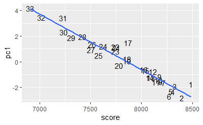

```r
p = ggplot(tibble(pc1 = pcan.ath$li[, 1], score = olympic$score, id = rownames(athletes)),
   aes(x = score, y = pc1, label = id)) + geom_text()
p + stat_smooth(method = "lm", se = FALSE)
```

> Scatterplot of the scores given as a supplementary variable and the first principal component. The points are labeled by their order in the data set. We can see a very strong correlation between this supplementary score variable and the first principal coordinate, why is it not a perfectly linear fit?
- Can see strong correlation between both variables
  - Note athelete#1 has highest score but not highest value for PC1 linear combo (why?)

#### How to choose k (#of dimentsions)?

- Step 1 of PCA = make screeplot of variances of the new variables (=eigen values)
  - Can’t decide how many dimensions needed before seeing this plot
  - Situations when PC are poorly defined (>2 or 3 PCs have similar variances) - shown in below screeplot
    - subspace corresponding to group of similar eigenvalues exist
    - This would generate a 3D space (by u2, u3, u4 matracies)
      - Vectors not meaningful individually & cant interpret loadings
      - B/c slight change in observations can give completely different set of 3 vectors (would generate same 3D sapce but have different loadings) = Unstable PC

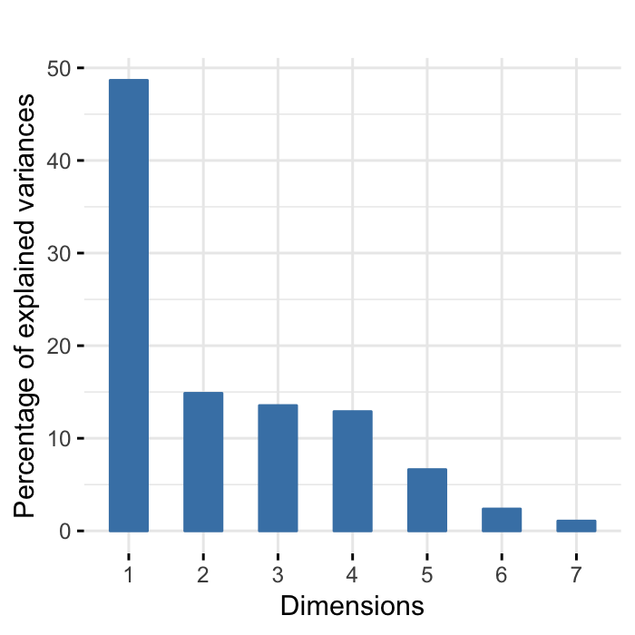

> A screeplot showing ‘dangerously’ similar variances. Choosing to cutoff at a hard threshold of 80% of the variance would give unstable PC plots. With so such cutoff, the axes corresponding to the 3D subspace of 3 similar eigenvalues are unstable and cannot be individually interpreted.

**PCA as an exploratory tool: using extra information** <sup>Return</sup>

- Unlike linear regression, PCA treats all variables the same (pre-processing to have equivalent sdevs via scaling)
  - Can map other continous variables/categorical factors onto plots to help interpret results
    - Usually have complementary info on samples (ex) diagonostic labels or cell types)
- Can use complementary variables to update interpretation (ex) Bioconductor SummarizedExperiment class -> 2nd best addtional columns of dataframe w/ numeric data)
  - This information is often stored within row names of the matrix
- Example for storing complementary variables in row names
  - use `substr()` to extract cell types & show screeplot + PCA

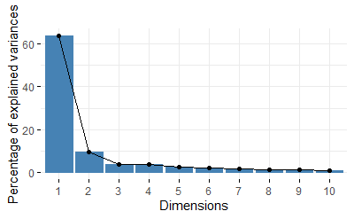

```r
#Screeplot
pcaMsig3 <- dudi.pca(Msig3transp, center = TRUE, scale = TRUE,
                    scannf = FALSE, nf = 4)
fviz_screeplot(pcaMsig3) + ggtitle("")
```

> T-cell expression PCA screeplot.

```r
ids = rownames(Msig3transp)
celltypes = factor(substr(ids, 7, 9))
status = factor(substr(ids, 1, 3))
table(celltypes)
```

```
celltypes
EFF MEM NAI
 10   9  11
```

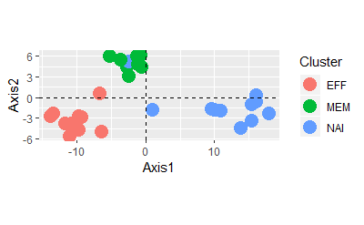

```r
#PCA plot
cbind(pcaMsig3$li, tibble(Cluster = celltypes, sample = ids)) %>%
ggplot(aes(x = Axis1, y = Axis2)) +
  geom_point(aes(color = Cluster), size = 5) +
  geom_hline(yintercept = 0, linetype = 2) +
  geom_vline(xintercept = 0, linetype = 2) +
  scale_color_discrete(name = "Cluster") + coord_fixed()
```

> PCA of gene expression for a subset of 156 genes involved in specificities of each of the three separate T-cell types: effector, naïve and memory. Again, we see that the plot is elongated along the the first axis, as that explains much of the variance. Notice that one of the T-cells seems to be mislabeled.